# Effects of Covid-19 on Tube Usage

Coursework1 230206405

Morgan Turney

March 2025

# Introduction

This project explores the effects of Covid-19 on transport in London, by investigating the daily number of journeys made on the Tube from 2019 - 2025.

We start by loading the required packages in r:

```r
library(zoo)
library(prophet)
```

# Data

Journey data is sourced from the TFL website linked below. https://tfl.gov.uk/corporate/publications-and-reports/network-demand-data

Data for each year from 2019 to 2025 inclusive was compiled into a single spreadsheet and uploaded into r for analysis.

# Initial Plot

First, let us create an initial plot of the data.

The code below opens and stores the data to a variable, and the date format used in the file is communicated to r. A line graph of journey count against date is then plotted.

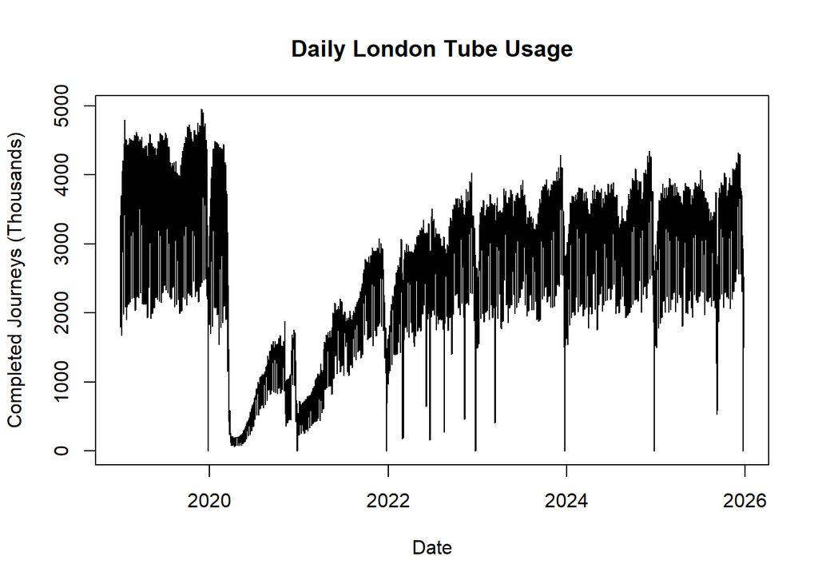

```r
tube.data <- read.csv("Data/Tube Data.csv")

tube.data$TravelDate <- as.Date(as.character(tube.data$TravelDate), format = "%Y%m%d")

plot(tube.data$TravelDate, tube.data$TubeJourneyCountThousands,
     main = "Daily London Tube Usage",
     xlab = "Date",
     ylab = "Completed Journeys (Thousands)",
     type = "l")
```

A significant drop to near zero service is observed at the beginning of 2020, which coincides with the first Covid lockdown coming into affect. Across 2021 and 2021, usage grows and then falls rapidly twice - the dates of these drops approximately line up with the dates of the second and third Covid lockdowns. Across 2022 an increasing trend is evident, which indicates tube usage recovering as government restrictions are gradually eased. From 2023-2025 inclusive, it appears that usage stabilises into a steady annual pattern with little evidence of a trend. It is relevant to note that the level of usage is significantly lower than that in 2019 (Pre-Covid).

# Refined Data Plot

The initial plot proves useful for showing the general effect of Covid-19 on tube journeys, but the significant number of data points makes the plot cluttered. To help investigate trend and seasonality more easily, we create a second plot using a weekly rolling average to combat this issue.

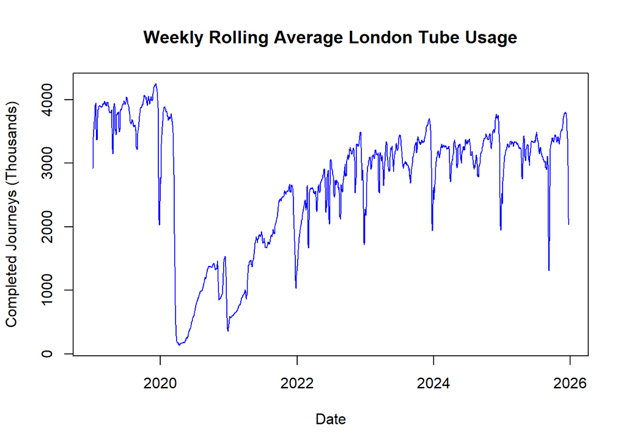

```r
tube.data.WRA <- rollmean(tube.data$TubeJourneyCountThousands, 7, fill = NA)

plot(tube.data$TravelDate, tube.data.WRA,
     main = "Weekly Rolling Average London Tube Usage",
     xlab = "Date",
     ylab = "Completed Journeys (Thousands)",
     type = "l",
     col = "blue")
```

On this plot, the drop in usage in the second Covid lockdown and annual Christmas periods is much more evident. Also, the seasonality pattern across 2023-2025 inclusive is much clearer. A major drop in usage is observed in September 2025, likely due to significant strike action causing widespread disruption for around a week.

# Before and After Covid-19

## General Comparison

The plots created so far indicate that Covid disruption is contained to the period of Jan 2020 - Dec 2022. The years 2020 and 2021 contain the most major drops in usage, and 2022 appears to be a period of recovery back to a steady level.

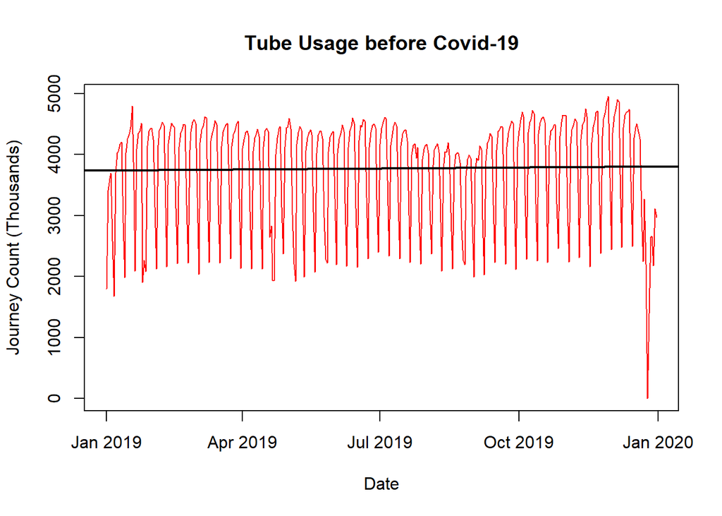

```r
preCovid.data <- subset(tube.data, TravelDate <= as.Date("2019-12-31"))

plot(preCovid.data$TravelDate, preCovid.data$TubeJourneyCountThousands,
     main = "Tube Usage before Covid-19",
     xlab = "Date",
     ylab = "Journey Count (Thousands)",
     type = "l",
     col = "red")

abline(lm(TubeJourneyCountThousands ~ TravelDate,
          data = preCovid.data),
       lwd = 2)
```

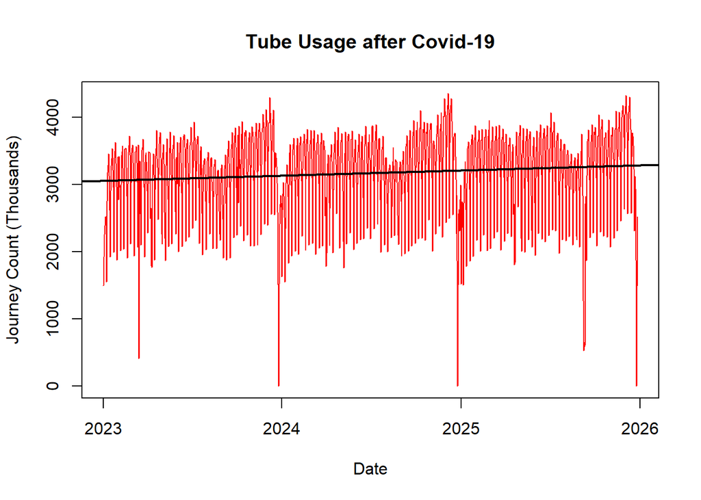

```r
postCovid.data <- subset(tube.data, TravelDate >= as.Date("2023-01-01"))

plot(postCovid.data$TravelDate, postCovid.data$TubeJourneyCountThousands,
     main = "Tube Usage after Covid-19",
     xlab = "Date",
     ylab = "Journey Count (Thousands)",
     type = "l",
     col = "red")

abline(lm(TubeJourneyCountThousands ~ TravelDate,
          data = postCovid.data),
       lwd = 2)
```

Comparing the two plots, we see that the annual pattern after Covid is very similar to before. However the trend lines show that average usage has decreased by around 750’000 journeys per day after Covid. It is also worth noting that there is an upward trend across 2023-2025, although it is very slight.

## Weekly Seasonality Comparison

It is logical to assume that transport data will assume weekly seasonality due to the five day work week. Having split tube usage data into pre and post Covid, let us now compare the weekly seasonality before Covid to that after using boxplots.

The “weekdays” function takes a given date, and returns the relevant day of the week. We apply this function to the data and store the output as a vector.

The “factor” function turns this vector into an ordered set of categories. The “levels” argument lets us specify the desired categories and their order. This function is necessary because r displays categories in alphabetical order by default.

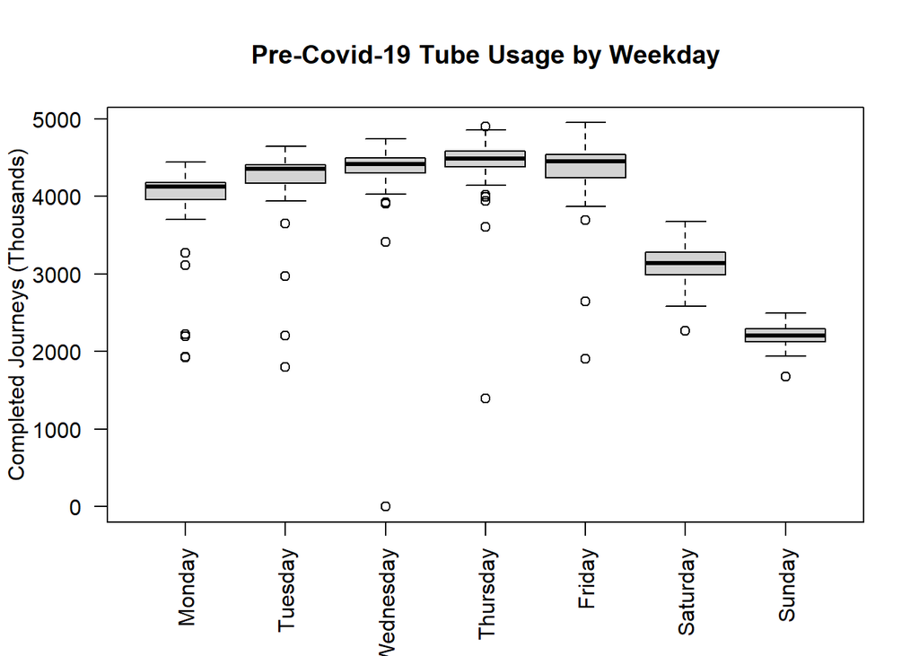

```r
preCovid.weekday <- weekdays(preCovid.data$TravelDate)
preCovid.weekday <- factor(preCovid.weekday,
                           levels=c("Monday","Tuesday","Wednesday","Thursday","Friday","Saturday","Sunday"))

boxplot(preCovid.data$TubeJourneyCountThousands ~ preCovid.weekday,
        xlab = "",
        las = 2,
        ylab = "Completed Journeys (Thousands)",
        main = "Pre-Covid-19 Tube Usage by Weekday")
```

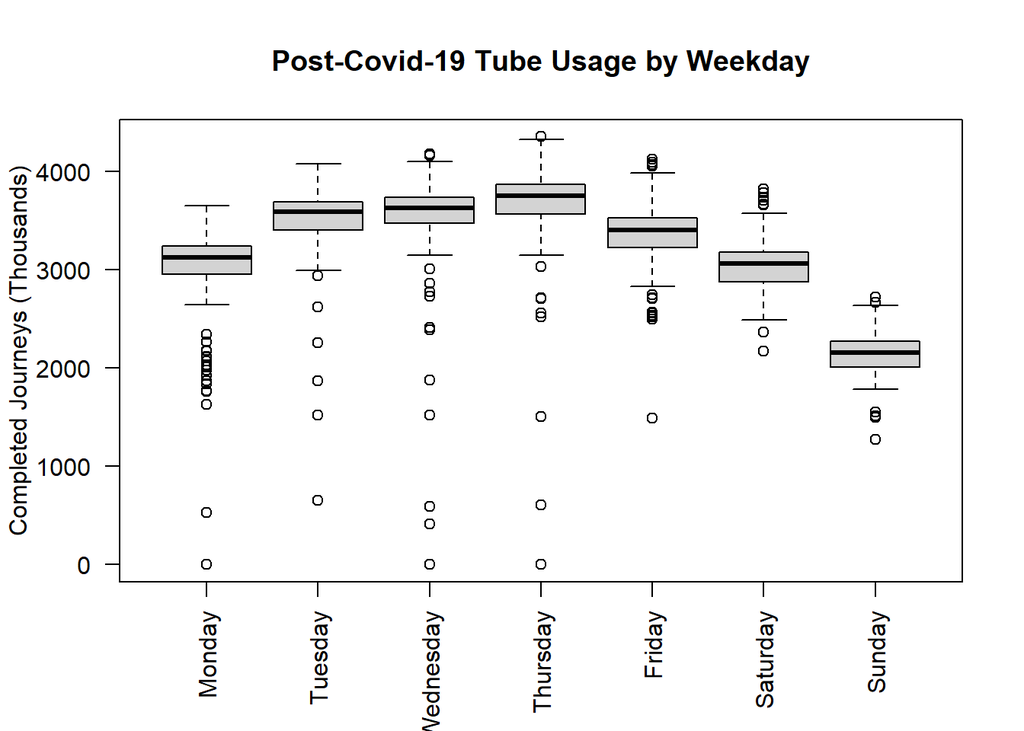

```r
postCovid.weekday <- weekdays(postCovid.data$TravelDate)
postCovid.weekday <- factor(postCovid.weekday,
                           levels=c("Monday","Tuesday","Wednesday","Thursday","Friday","Saturday","Sunday"))

boxplot(postCovid.data$TubeJourneyCountThousands ~ postCovid.weekday,
        xlab = "",
        las = 2,
        ylab = "Completed Journeys (Thousands)",
        main = "Post-Covid-19 Tube Usage by Weekday")
```

Both before and after Covid, tube usage is higher on workdays than on weekends. Before Covid, usage maintained a similar level from Monday-Friday, whereas after Covid usage is slightly lower on Monday and Friday when compared with Tuesday-Thursday. Sunday remains the day with the lowest tube usage by a significant margin. As mentioned previously, average usage for all days after Covid is significantly lower than before Covid.

## Annual Seasonality

Line plots of pre and post Covid data indicate that some annual seasonality exists. However creating interpretable plots of annual seasonality is difficult due to the presence of dominant weekly seasonality.  
Despite this, describing the annual seasonality is still possible. A clear annual drop to near zero usage exists over the Christmas period, with service stopping on Christmas day. Furthermore, a smaller but significant drop in usage occurs in August each year, potentially due to School holidays.

# Prophet forecasting 2026

We now move to focus on the post-Covid data from 2023-2025. Let us use Prophet by meta to foercast tube usage for 2026 based off the previous three years of data.

```r
prophet.data <- data.frame(ds = postCovid.data$TravelDate,
                           y = postCovid.data$TubeJourneyCountThousands)

prophet.model <- prophet(prophet.data)
```

```
## Disabling daily seasonality. Run prophet with daily.seasonality=TRUE to override this.
```

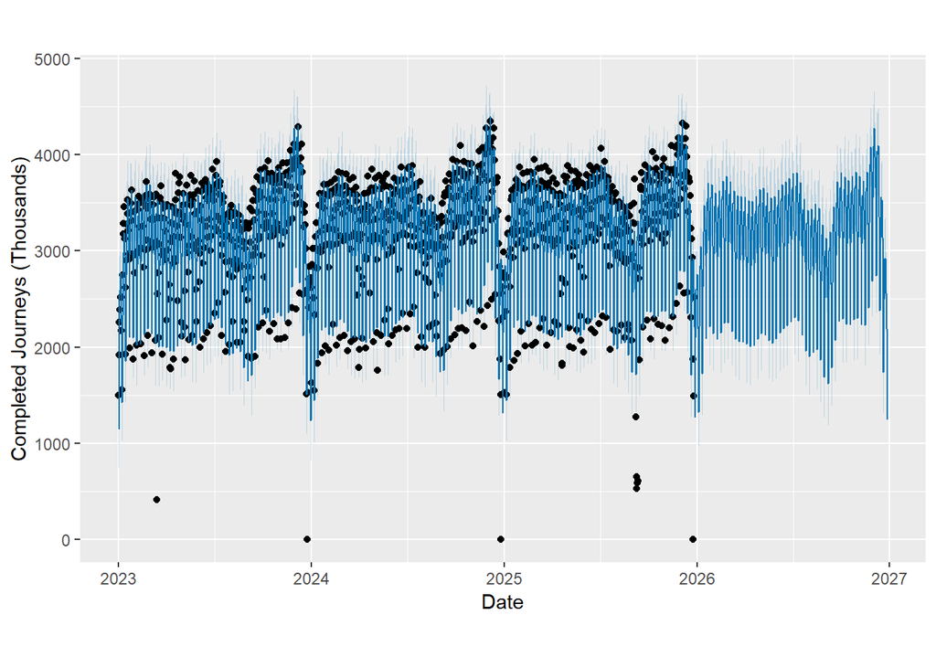

```r
future.dates <- make_future_dataframe(prophet.model, periods = 365)

prophet.forecast <- predict(prophet.model, future.dates)

plot(prophet.model, prophet.forecast,
     main = "Forecast of London Tube Usage for 2026",
     xlab = "Date",
     ylab = "Completed Journeys (Thousands)")
```

The forecast yields a usage pattern which is very similar to those of 2023-2026 as expected. Similar events such as usage drops in Summer and over Christmas are once again obsered as previously discussed.

# Conclusion

This analysis shows that the biggest effect of Covid on tube usage is an overall reduction in demand, evidenced by an approximate 20% reduction in average daily journeys completed. This is likely due to a change to working culture over Covid - remote working is far more common now than it ever was before Covid. This means less people are commuting to their employers offices each day, so less people are using the tube each day. Furthermore, usage on Mondays and Fridays has slightly decreased compared to the midweek. This could indicate that working remotely is more popular on these days, and therefore tube usage will peak from Tuesday-Thursday. Both before and after Covid, demand on weekends is significantly lower than demand on workdays - this suggests that commuters remain the largest user group of the tube.

Annual seasonality appears to be present, and can be explained by a number of factors. The significant drop at Christmas is caused by a widespread reduction in services during the festive period. The drop in summer could be due to school holidays - fewer students use the tube to commute to school. More workers taking holidays in the summer, and therefore leaving London for a period, could also contribute.

The anomalous usage drop in September 2025 can easily be explained by a significant tube strike occurring from 7-Sep to 11-Sep, which caused widespread disruption.

Finally, the Prophet forecast suggests that tube usage in 2026 will follow a similar pattern to previous years, with no clear change in trend.